# A Simple Animation Example

dagtann

October 18, 2015

With the help of the animation package it becomes simple to create animated graphs in R. Each such graph consists of a sequence of plots that are converted into the requested output format. This example generates a simple animated gif file.

```r
## --- Preamble --------------------------------------------
rm(list = ls())                               ## start clean
library('animation')
```

Let’s generate some data for plotting. It is necessary to decide on the number of frames first. To keep things simple this example generates only $10$ frames.

```r
# --- 1) Generate some plotting data -----------------------
set.seed(8734)                       ## ensure replicability
noFrames <- 10             ## how many frames wanted in ani?
dta <- data.frame(                          ## data for plot
  x = 1:noFrames, y = runif(noFrames)
)
head(dta)
```

```
##   x         y
## 1 1 0.4580676
## 2 2 0.3929948
## 3 3 0.8713066
## 4 4 0.8860061
## 5 5 0.8109371
## 6 6 0.8152181
```

Now for the tricky part. This example uses **saveGIF()** from the animation package. This as any other convenience function from the animation package opens a graphical device, then generates a sequence of plots, and finally saves the result in the requested format.[^1] The sequence of plots should be based on an expression that is reapplied to each outputted frame. It is best to write a function for that purpose. The function below takes our rexample data, creates an empty plot and finally loops over each row to plot it.

```r
frames <- function(data, domain, range, maxFrames) {
  ## data ... the data frame to plot
  ## index ... domain of the function
  ## value ... range of the function
  ## maxFrames ... how many frames are there?
  plot(            ## generate an empty plot with fixed dims
    x = 0, y = 0, xlim = c(1, maxFrames), ylim = c(0, 1),
    type ='n', xlab = 'Domain', ylab = 'Range'
  )
  for(i in 1:nrow(data)) {
    lines(
      x = c(data[i-1, domain], data[i, domain]),
      y = c(data[i-1, range], data[i, range])
    )
    points(
      x = data[i, domain], y = data[i, range],
      pch = 16, col = 'black'
    )
  }
}
```

If executed by itself the function merely returns the last plot. In order to get the entire sequence it must be wrapped into the **saveGif()** function. By default the graph is saved into your current working directory.

```r
saveGIF(
  lapply(1:noFrames, ## listwise apply FUN to elements 1:noFrames
    FUN = function(k) {     ## anonymous function to lapply
    frames(                 ## plotting function from above
      data = dta[1:k, ], domain = 'x', range = 'y',
      maxFrames = noFrames
    )
  }
  ),
  movie.name = 'simpleAnimation.gif',
  interval = .3                          ## animation speed
)
```

```
## Executing:
## 'convert' -loop 0 -delay 30 Rplot1.png Rplot2.png Rplot3.png
##     Rplot4.png Rplot5.png Rplot6.png Rplot7.png Rplot8.png
##     Rplot9.png Rplot10.png 'simpleAnimation.gif'
```

```
## Output at: simpleAnimation.gif
```

Here is the result:

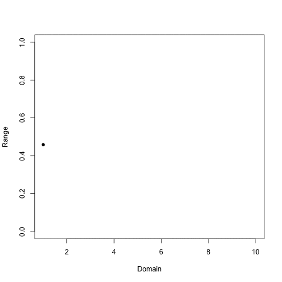

[^1]: Note that **saveGIF()** requires ImageMagick to be installed on your system.